# Discbot Sample Weighing

JH

6/10/2015

Sample weights are an essential part of the total discbot scan procedure. Weight is used to:

- monitor conditioning
- identify substantial changes in samples (e.g. breakages)
- untangle identification issues (e.g. lost barcodes)

In regards to conditionining, the (somewhat arbitrary) goal is to keep moisture content, $w$, variation to within $\Delta w = 1\%$. Since

$w = \frac{M_w}{M_o} = \frac{M - M_o}{M_o} = \frac{M}{M_o} - 1$

need $\Delta M < M_o \Delta w$ (no error associated with $M_o$ since it never needs to be measured).

## Theoretical Maximum Weight

System designed to handle up to 800 mm diameter discs, 20 mm thick. An average air-dry density of 500 kg/m^3 would be high.

```r
V = pi*(0.8/2)^2*0.02 / 2
W = 500 * V # 2.5 kg
```

So a scale with a 3kg max would be ok.

## Typical Sample Weights

Previous half-disc weights:

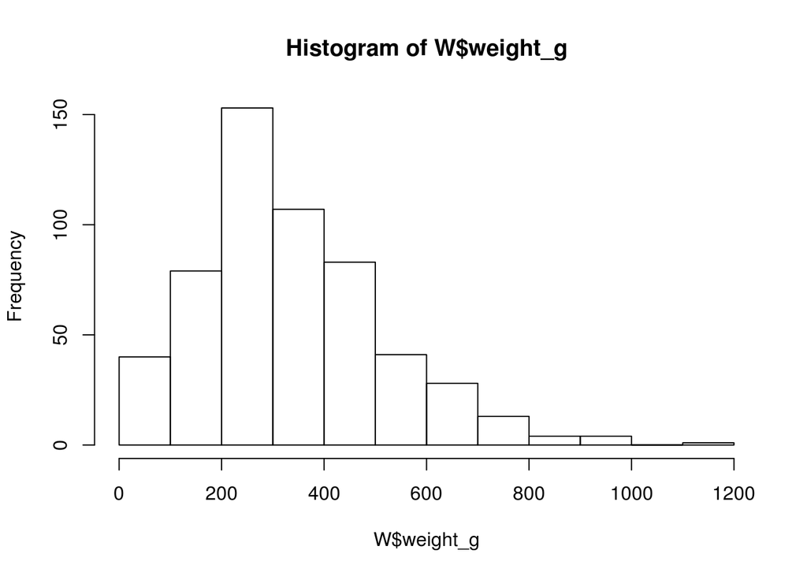

```r
library(RODBC)
ch = odbcConnect('ifs16',uid='harringj',pwd='letme1n')
W = sqlQuery(ch, 'select * from discWeights')
hist(W$weight_g)
```

```r
summary(W$weight_g)
```

```
##    Min. 1st Qu.  Median    Mean 3rd Qu.    Max.
##     0.0   218.4   302.9   334.1   431.8  1169.0
```

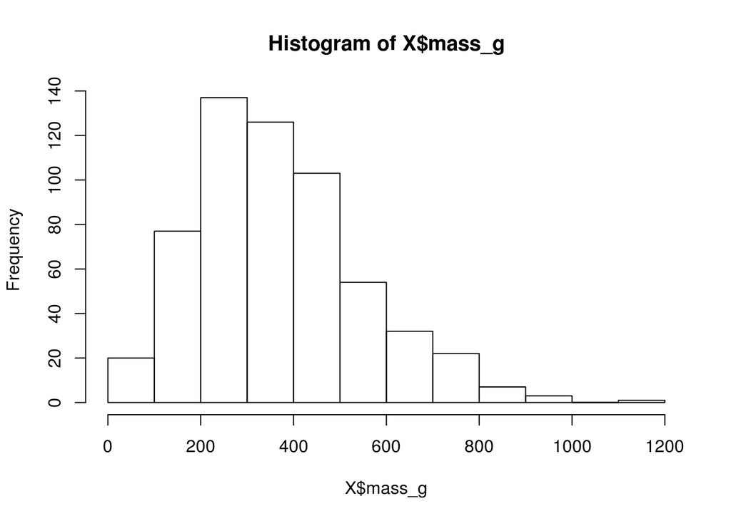

```r
X = sqlQuery(ch, 'select mass_g from XRAscans')
hist(X$mass_g)
```

```r
summary(X$mass_g)
```

```
##    Min. 1st Qu.  Median    Mean 3rd Qu.    Max.
##    53.3   239.6   344.6   369.1   470.5  1196.0
```

Half-discs processed to date range from 50 to 1200 g, typically 300 g. These are air-dry values and correspond roughly to $w=12\%$. So oven-dry sample weights are $M_o = M/(1 + w)$ or 45–1070 g, typically 270 g.

So for $\Delta w < 1\%$, $\Delta M < 0.5$ g, based on extreme sample weight or $\Delta M < 3.0$ g based on typical. These are not particulary demanding requirements.

## Green Discs

If we ever switch to a green whole-disc methodology then the sample weights would obviously be higher.

The maximum weight would then be 11.0584061 kg, or half that if we had to cut in half to accomodate in the scanner (currently limited to samples <400 mm wide). On the other hand the need for precision would be much reduced.

Seems best to not try to future proof at this stage